# ST 790 Assignment 1

David Elsheimer and Jimmy Hickey

9/1/2020

## Instruction

This assignment consists of $4$ problems. The assignment is due on **Tuesday, September 1** at 11:59pm EDT. Please submit your assignment electronically through the **Moodle** webpage. The assignment can be done as a group with at most 3 members per group (please include the name of the group members on the front page of the assignment).

# Problem 1

Download the political blogs dataset from [here](http://www-personal.umich.edu/~mejn/netdata/). Now find the say, top ten, most “central” or “important” vertices via e.g., closeness centrality, betweeness centrality, Katz centrality, page-rank centrality, and hubs/authority centrality. Does the blogs that you identified similar to that in Table 1 through Table 3 of [Adamic and Glance](http://www.ramb.ethz.ch/CDstore/www2005-ws/workshop/wf10/AdamicGlanceBlogWWW.pdf) ?

```r
g<-read.graph("polblogs.gml",format=c("gml"))
summary(g)
```

```
## IGRAPH 6b51b87 D--- 1490 19090 --
## + attr: id (v/n), label (v/c), value (v/n), source (v/c)
```

```r
labels <- V(g)$label
val <- V(g)$value

closeness <- closeness(g)
betweenness <- betweenness(g)
pg <- page_rank(g)$vector
katz <- alpha_centrality(g, alpha = 0.05)
hub <- hub_score(g)$vector
auth <- authority_score(g)$vector

nodeinfo <- as.data.frame(labels)
nodeinfo <- mutate(nodeinfo, val = val, close=closeness, between=betweenness, pg = pg,
                   katz = katz, hub = hub, auth = auth)

pgrank    <- nodeinfo %>% arrange(desc(close)) %>%  select(labels) %>%head(n=10)

pgranklib <- nodeinfo %>% filter(val == 0) %>%
  arrange(desc(pg)) %>%  select(labels) %>%head(n=10)

pgrankcon <- nodeinfo %>% filter(val == 1) %>%
  arrange(desc(pg)) %>%  select(labels) %>%head(n=10)


closerank    <- nodeinfo %>% arrange(desc(close)) %>%  select(labels) %>%head(n=10)

closeranklib <- nodeinfo %>% filter(val == 0) %>%
  arrange(desc(close)) %>%  select(labels) %>%head(n=10)

closerankcon <- nodeinfo %>% filter(val == 1) %>%
  arrange(desc(close)) %>%  select(labels) %>%head(n=10)


betweenrank    <- nodeinfo %>% arrange(desc(between)) %>%  select(labels) %>%head(n=10)

betweenranklib <- nodeinfo %>% filter(val == 0) %>%
  arrange(desc(between)) %>%  select(labels) %>%head(n=10)

betweenrankcon <- nodeinfo %>% filter(val == 1) %>%
  arrange(desc(between)) %>%  select(labels) %>%head(n=10)

katzrank    <- nodeinfo %>% arrange(desc(katz)) %>%  select(labels) %>%head(n=10)

katzranklib <- nodeinfo %>% filter(val == 0) %>%
  arrange(desc(katz)) %>%  select(labels) %>%head(n=10)

katzrankcon <- nodeinfo %>% filter(val == 1) %>%
  arrange(desc(katz)) %>%  select(labels) %>%head(n=10)

hubrank    <- nodeinfo %>% arrange(desc(hub)) %>%  select(labels) %>%head(n=10)

hubranklib <- nodeinfo %>% filter(val == 0) %>%
  arrange(desc(hub)) %>%  select(labels) %>%head(n=10)

hubrankcon <- nodeinfo %>% filter(val == 1) %>%
  arrange(desc(hub)) %>%  select(labels) %>%head(n=10)



authrank    <- nodeinfo %>% arrange(desc(auth)) %>%  select(labels) %>%head(n=10)

authranklib <- nodeinfo %>% filter(val == 0) %>%
  arrange(desc(auth)) %>%  select(labels) %>%head(n=10)

authrankcon <- nodeinfo %>% filter(val == 1) %>%
  arrange(desc(auth)) %>%  select(labels) %>%head(n=10)

rankings1 <- as.data.frame(cbind(pgrank, closerank, betweenrank))

rankings2 <- as.data.frame(cbind(katzrank, hubrank, authrank))
colnames(rankings1) <- c("Page rank", "Closeness", "Betweeness")
colnames(rankings2) <- c("Katz", "Hub", "Authority")

librankings1 <- as.data.frame(cbind(pgranklib, closeranklib, betweenranklib))

librankings2 <- as.data.frame(cbind(katzranklib, hubranklib, authranklib))
colnames(librankings1) <- c("Page rank", "Closeness", "Betweeness")
colnames(librankings2) <- c("Katz", "Hub", "Authority")

conrankings1 <- as.data.frame(cbind(pgrankcon, closerankcon, betweenrankcon))

conrankings2 <- as.data.frame(cbind(katzrankcon, hubrankcon, authrankcon))
colnames(conrankings1) <- c("Page rank", "Closeness", "Betweeness")
colnames(conrankings2) <- c("Katz", "Hub", "Authority")
```

# Problem 2

Skim through this [article](https://arxiv.org/pdf/0706.1062.pdf) by Clauset, Shalizi, and Newman. Now download the yeast metabolic network dataset from [here](http://tuvalu.santafe.edu/~aaronc/powerlaws/data.htm). Fit a power-law to the degree distribution for this dataset. Do you think the degree distribution for this network follows a power-law ?

```r
library(igraph)
g2 <- read_graph("nodes.txt")
cg <- components(g2)
lcc <- decompose(g2, min.vertices = max(cg$csize))[[1]];

deg_dist <- degree_distribution(lcc, cumulative = TRUE)
mod <- lm(log(deg_dist,10) ~ log(1:length(deg_dist),10))
mod$coefficients ##``Estimate'' of exponent in power-law
```

```
##                 (Intercept) log(1:length(deg_dist), 10)
##                   0.8195035                  -2.3120220
```

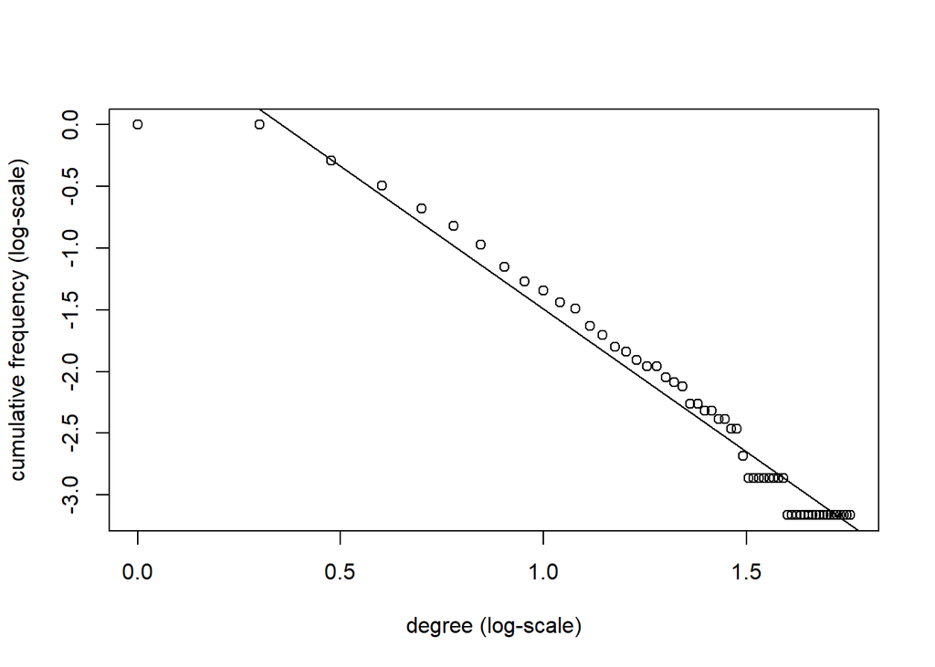

```r
plot(log(1:length(deg_dist),10),log(deg_dist,10),
xlab = "degree (log-scale)", ylab = "cumulative frequency (log-scale)",abline(mod))
```

Based on the above comparison of the data to the fitted power law, it appears that the degree distribution does indeed follow a power law.

# Problem 3

Let $X_1, X_2, \dots, X_n$ be i.i.d random variables. The sample variance of the $X_i$ can be written as a $U$-statistics, i.e.,
$$s^2 = \frac{2}{n(n-1)} \sum_{i < j} \frac{1}{2} (X_i - X_j)^2.$$
Suppose now the $X_i$ are i.i.d Bernoulli random variables with probability of success $p \in (0,1)$. Derive a non-degenerate limiting distribution for $s^2$. What happens to this limiting distribution when $p = 1/2$ ?

https://stats.stackexchange.com/questions/105337/asymptotic-distribution-of-sample-variance-of-non-normal-sample

4th central moment: https://en.wikipedia.org/wiki/Bernoulli_distribution#Higher_moments_and_cumulants

# Problem 4

We now consider the problem of goodness-of-fit test for Erdos-Renyi graphs. More specifically, let $\mathcal{G} = \mathcal{G}(n,m,p, q)$ be a random graph model defined as follows. A graph $G$ is an instance of $\mathcal{G}$ if $G$ is an undirected graph on $n$ vertices with adjacency matrix $\mathbf{A} = (a_{ij})$ of the form
$$\begin{gather*}
a_{ij} \sim \mathrm{Bernoulli}(q), \quad \text{if $i \in \mathcal{S}$ and $j \in \mathcal{S}$} \\
a_{ij} \sim \mathrm{Bernoulli}(p), \quad \text{otherwise}.
\end{gather*}$$
Here $\mathcal{S} \subset \{1,2,\dots,n\}$ is a subset of vertices with $|\mathcal{S}| = m$ and we have assumed that $q > p \in (0,1)$. Note that $m = 0$ corresponds to the normal Erdos-Renyi graph and $m > 0$ corresponds to a random graph model where there is a subset $\mathcal{S}$ of $m$ vertices with larger communication probability $q$ among themselves.

Given a graph $G \sim \mathcal{G}(n,m,p,q)$, we are interested in testing the null hypothesis $\mathbb{H}_0 \colon |\mathcal{S}| = m = 0$ against the alternative hypothesis that $\mathbb{H}_A \colon |\mathcal{S}| = m > 0$.

For this problem, we will use two test statistics. The first test statistic is $\Delta$, the maximum degree and the second test statistic is $\tau$, the number of triangles. More specifically, given a graph $G \sim \mathcal{G}(n,m,p,q)$, and suppose we are using $\Delta$ as the test statistic. Then we will reject the null hypothesis if $\Delta$ exceeds some threshold $c$.

Perform a simulation study to determine the power of the test procedures when we use (1) $\Delta$ as the test statistic and (2) when we use $\tau$ as the test statistic. To reduce computation time, set $n = 1000$, $p = 0.4$, and $q = 0.6$ and let $m \in \{10,25,50,100\}$. Report a table for the power of the test statistics as a function of $m$.

**Hint** To generate a graph from the $\mathcal{G}(n,m,p,q)$ when $m > 0$, you can use the following igraph chunk.

```r
library(igraph)
p <- 0.4
q <- 0.6
n <- 1000
m <- 10
B <- matrix(c(p,p,p,q),nrow = 2)
A <- sbm.game(n = n, pref.matrix = B, block.sizes = c(n-m,m))

delta = max(degree(A))
delta
```

```
## [1] 449
```

```r
sum(count_triangles(A))/3
```

```
## [1] 10616714
```

```r
# naive estimate of edge probability
num_edges = ecount(A)
phat =  num_edges / choose(n, 2)


x = sqrt( 2 * log(n) )
k = n*phat + x * sqrt((n*phat * (1-phat)))

# Extreme Value Distributions package for Gumbel distribution

library(evd)

pgumbel(delta, 0 , 1) - pgumbel(k, 0 , 1)
```

```
## [1] 0
```

```r
tau = sum(count_triangles(A))/3


tau_test = (tau - choose(n, 3)*phat^3) / ( (n-2)*phat^2*sqrt(choose(n,2) *phat * (1-phat)) )
```

The maximum degree and the number of triangles can be easily determined via

```r
max(degree(A))
```

```
## [1] 449
```

```r
sum(count_triangles(A))/3
```

```
## [1] 10616714
```